# Darwin’s finches: Intraspecific morphological variation

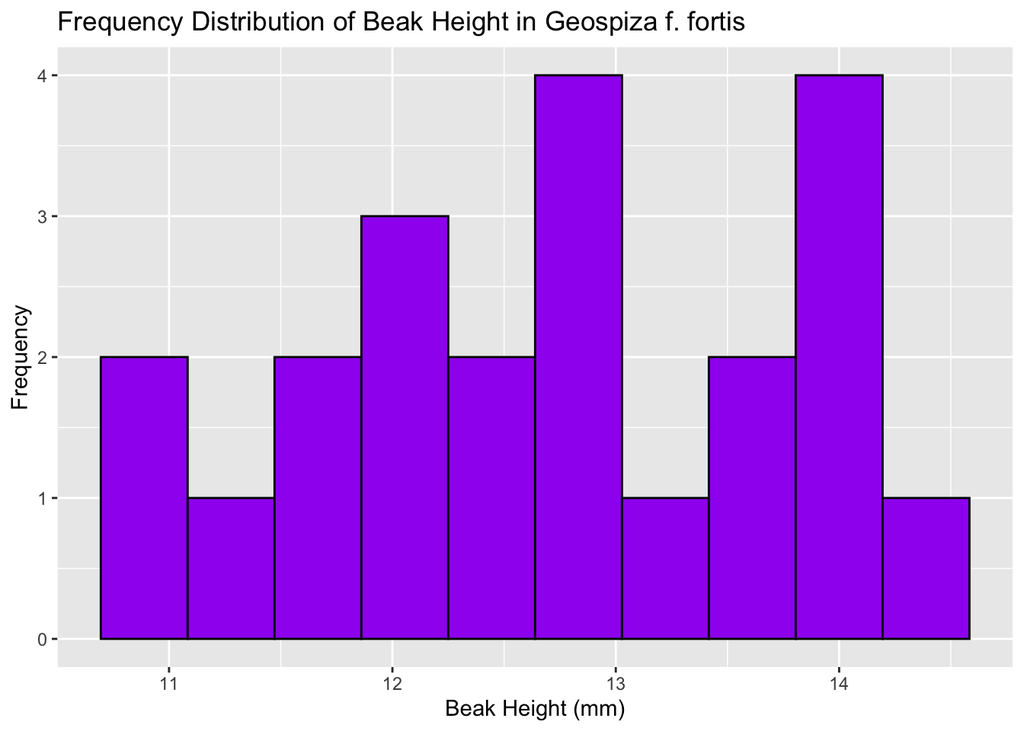

```r
ggplot(df_fortis, aes(x = BeakH)) +
  geom_histogram(bins = 10, fill = "purple", color = "black") +
  xlab("Beak Height (mm)") +
  ylab("Frequency") +
  ggtitle("Frequency Distribution of Beak Height in Geospiza f. fortis")
```

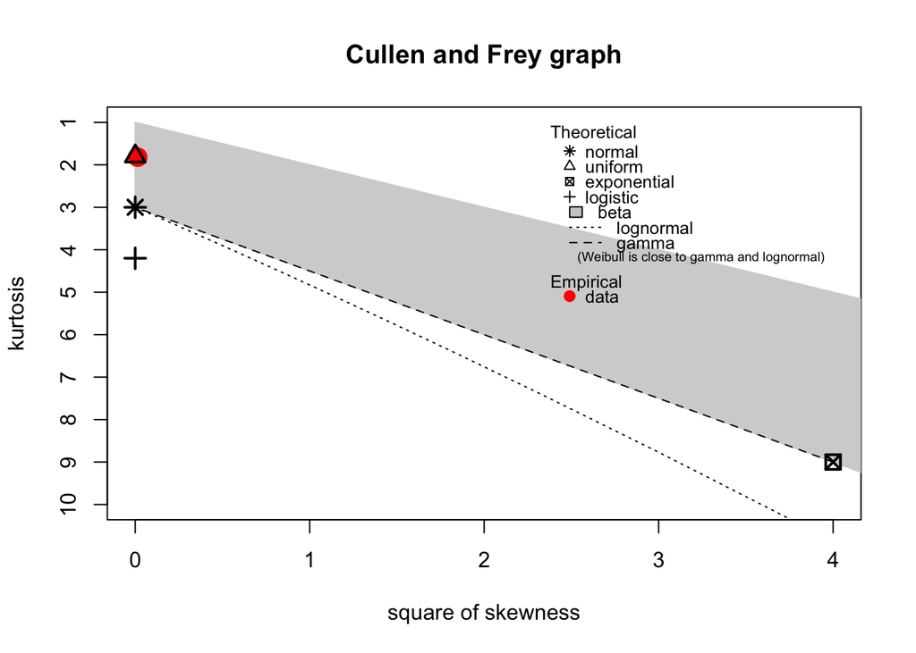

```
## summary statistics
## ------
## min:  11   max:  14.5
## median:  13
## mean:  12.72273
## estimated sd:  1.075233
## estimated skewness:  -0.1186003
## estimated kurtosis:  1.820378
```

```r
descdist(df_fortis$BeakH, discrete = FALSE)
```

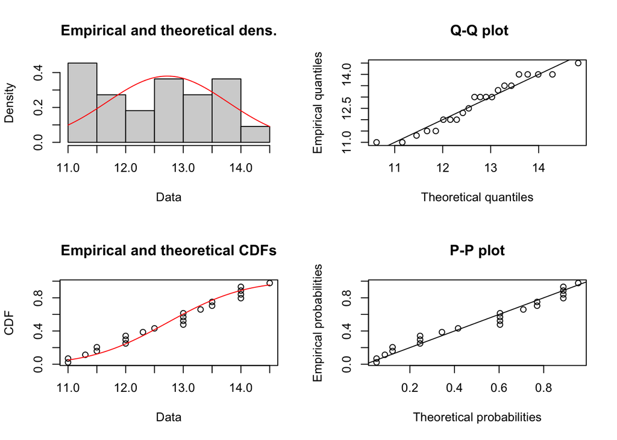

```r
fit.weibull <- fitdist(df_fortis$BeakH, "weibull")
fit.norm <- fitdist(df_fortis$BeakH, "norm")

#checking fit for normal distriibution

plot(fit.norm) ##Looks more like Normal dist, based on Q-Q plot
```

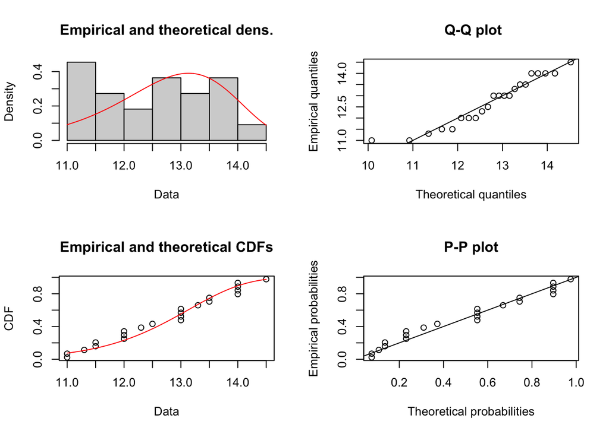

```r
#Weibull Distribution fit-check

plot(fit.weibull) ##Q-Q plot has an outlier on the low end likely to be a worse fit
```

```r
# Calculate skewness
skewness_value <- skewness(df_fortis$BeakH)
cat("Skewness of Beak Height in G. f. fortis:", skewness_value, "\n")
```

```
## Skewness of Beak Height in G. f. fortis: -0.1103557
```

```r
# Calculate kurtosis
kurtosis_value <- kurtosis(df_fortis$BeakH)
cat("Kurtosis of Beak Height in G. f. fortis:", kurtosis_value, "\n")
```

```
## Kurtosis of Beak Height in G. f. fortis: 1.811063
```

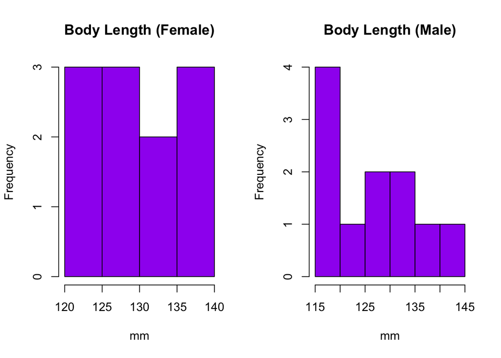

```r
# Separate data by sex
bodyL_female <- df_fortis %>% filter(sex == "F") %>% pull(BodyL)
bodyL_male <- df_fortis %>% filter(sex == "M") %>% pull(BodyL)


# Visual inspection: Histograms
par(mfrow = c(1, 2))
hist(bodyL_female, main = "Body Length (Female)", col = "purple", xlab = "mm")
hist(bodyL_male, main = "Body Length (Male)", col = "purple", xlab = "mm")
```

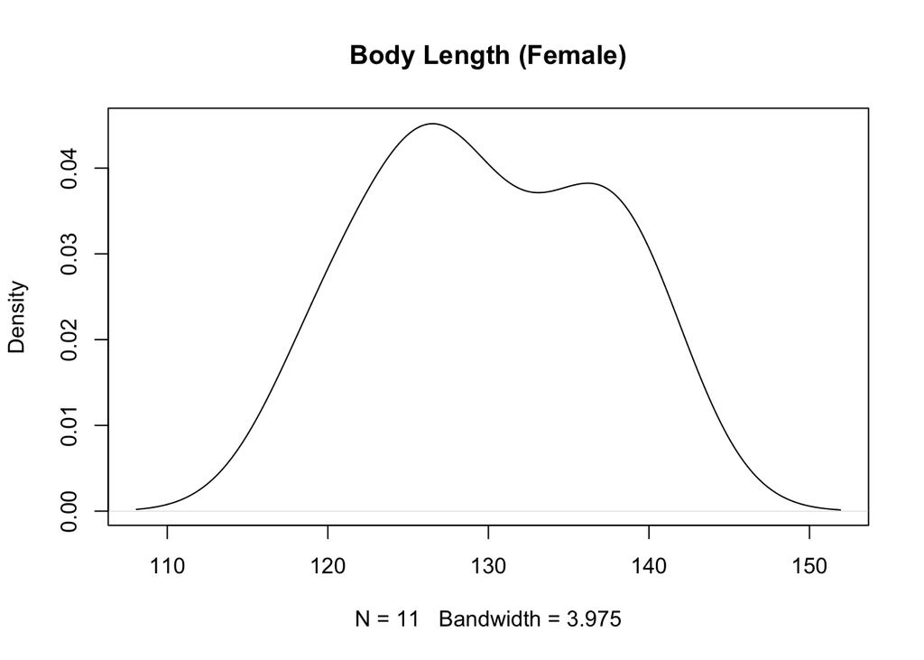

```r
par(mfrow = c(1, 1))

# Visual inspection: Density plots
plot(density(bodyL_female), main = "Body Length (Female)")
```

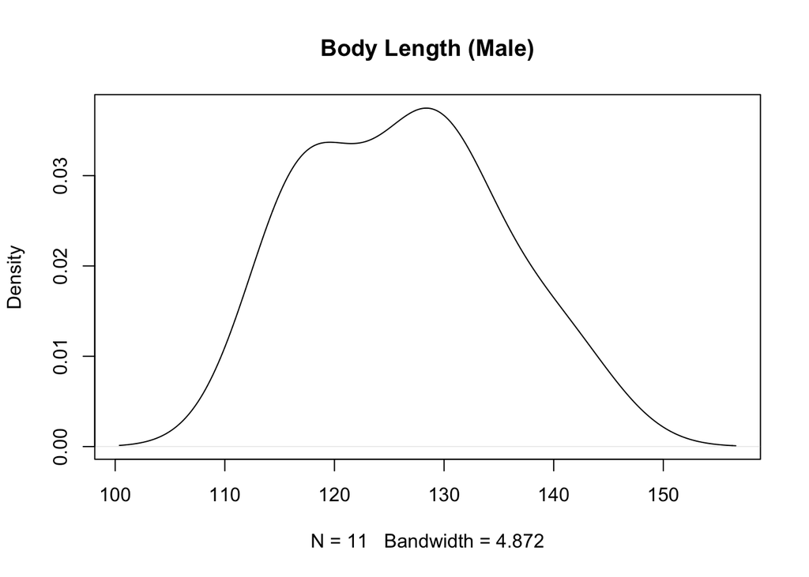

```r
plot(density(bodyL_male), main = "Body Length (Male)")
```

```r
# Statistical test for normality (Shapiro-Wilk)
shapiro.test(bodyL_female)
```

```
##
##  Shapiro-Wilk normality test
##
## data:  bodyL_female
## W = 0.91685, p-value = 0.2933
```

```r
shapiro.test(bodyL_male)
```

```
##
##  Shapiro-Wilk normality test
##
## data:  bodyL_male
## W = 0.93669, p-value = 0.4824
```

```r
# Levene's test


leveneTest(BodyL ~ sex, data = df_fortis)
```

```
## Levene's Test for Homogeneity of Variance (center = median)
##       Df F value Pr(>F)
## group  1  0.2626  0.614
##       20
```

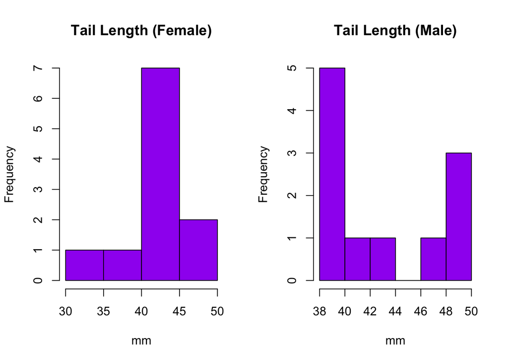

```r
# Separate data by sex
tailL_female <- df_fortis %>% filter(sex == "F") %>% pull(TailL)
tailL_male <- df_fortis %>% filter(sex == "M") %>% pull(TailL)

# Visual inspection: Histograms
par(mfrow = c(1, 2))
hist(tailL_female, main = "Tail Length (Female)", col = "purple", xlab = "mm")
hist(tailL_male, main = "Tail Length (Male)", col= "purple", xlab = "mm")
```

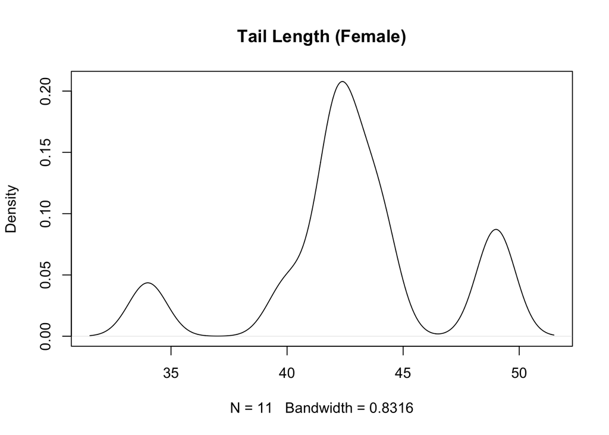

```r
par(mfrow = c(1, 1))

# Visual inspection: Density plots
plot(density(tailL_female), main = "Tail Length (Female)")
```

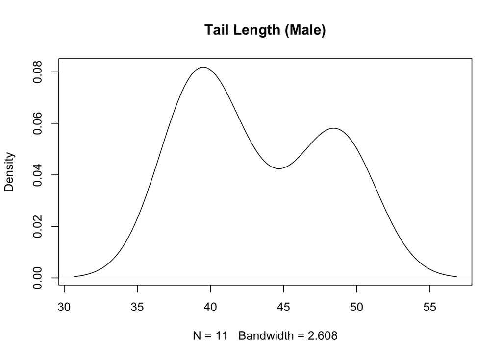

```r
plot(density(tailL_male), main = "Tail Length (Male)")
```

```r
# Statistical test for normality (Shapiro-Wilk)
shapiro.test(tailL_female)
```

```
##
##  Shapiro-Wilk normality test
##
## data:  tailL_female
## W = 0.88988, p-value = 0.1386
```

```r
shapiro.test(tailL_male)
```

```
##
##  Shapiro-Wilk normality test
##
## data:  tailL_male
## W = 0.79389, p-value = 0.007818
```

```r
# Statistical test for equality of variances (Levene's test)
leveneTest(TailL ~ sex, data = df_fortis)
```

```
## Levene's Test for Homogeneity of Variance (center = median)
##       Df F value Pr(>F)
## group  1  1.0906 0.3088
##       20
```

## References

Ben-Shachar M, Lüdecke D, Makowski D (2020). effectsize: Estimation of Effect Size Indices and Standardized Parameters. Journal of Open Source Software, 5(56), 2815. doi: 10.21105/joss.02815

Hester J, Bryan J (2024). *glue: Interpreted String Literals*. R package version 1.8.0, https://CRAN.R-project.org/package=glue.

Komsta L, Novomestky F (2022). *moments: Moments, Cumulants, Skewness, Kurtosis and Related Tests*. R package version 0.14.1, https://CRAN.R-project.org/package=moments.

Marie Laure Delignette-Muller, Christophe Dutang (2015). fitdistrplus: An R Package for Fitting Distributions. Journal of Statistical Software, 64(4), 1-34. DOI 10.18637/jss.v064.i04.

[output not shown]

[output not shown]

[output not shown]

Xie Y (2025). *knitr: A General-Purpose Package for Dynamic Report Generation in R*. R package version 1.50, https://yihui.org/knitr/.